# Quantified Self Movement Data Analysis

### Coursera-Practical Machine Learning Project

## Introduction

Using devices such as Jawbone Up, Nike FuelBand, and Fitbit it is now possible to collect a large amount of data about personal activity relatively inexpensively. These type of devices are part of the quantified self movement - a group of enthusiasts who take measurements about themselves regularly to improve their health, to find patterns in their behavior, or because they are tech geeks. One thing that people regularly do is quantify how much of a particular activity they do, but they rarely quantify how well they do it.

In this project, we will use data from accelerometers on the belt, forearm, arm, and dumbell of 6 participants to predict the manner in which they did the barbell lifts correctly and incorrectly in 5 different ways.

More information is available from the website here: http://groupware.les.inf.puc-rio.br/har

**Data source:**

*Training data:* https://d396qusza40orc.cloudfront.net/predmachlearn/pml-training.csv

*Testing data:* https://d396qusza40orc.cloudfront.net/predmachlearn/pml-testing.csv

## Project Goal

The goal of project is to predict the manner in which they did the exercise. This is the “classe” variable in the training set. You may use any of the other variables to predict with. You should create a report describing how you built your model, how you used cross validation, what you think the expected out of sample error is, and why you made the choices you did. You will also use your prediction model to predict 20 different test cases.

1. Your submission should consist of a link to a Github repo with your R markdown and compiled HTML file describing your analysis. Please constrain the text of the writeup to < 2000 words and the number of figures to be less than 5. It will make it easier for the graders if you submit a repo with a gh-pages branch so the HTML page can be viewed online (and you always want to make it easy on graders).
2. You should also apply your machine learning algorithm to the 20 test cases available in the test data above. Please submit your predictions in appropriate format to the programming assignment for automated grading. See the programming assignment for additional details.

## Data Preprocessing

Downloading and read the data sources of training data and testing data to data frams.

```r
#download data
trainUrl <-"https://d396qusza40orc.cloudfront.net/predmachlearn/pml-training.csv"
testUrl <- "https://d396qusza40orc.cloudfront.net/predmachlearn/pml-testing.csv"
trainFile <- "./pml-training.csv"
testFile  <- "./pml-testing.csv"
if (!file.exists(trainFile)) {
  download.file(trainUrl, destfile=trainFile)
}
if (!file.exists(testFile)) {
  download.file(testUrl, destfile=testFile)
}
#read data
trainRaw<-read.csv("./pml-training.csv")
testRaw<-read.csv("./pml-testing.csv")
```

Loading required library for this project

```r
library(caret);library(rpart);library(rpart.plot);library(randomForest);library(corrplot);library(ggplot2)
```

#### Initial check on data

Traning data contain 160 variables and 19622 observations, the testing data contain 160 variables and 20 observations. Also, there are only 406 observations do not have missing value in training data, and all observations have missing value in testing data.

```r
dim(trainRaw)
```

```
## [1] 19622   160
```

```r
dim(testRaw)
```

```
## [1]  20 160
```

```r
sum(complete.cases(trainRaw))
```

```
## [1] 406
```

```r
sum(complete.cases(testRaw))
```

```
## [1] 0
```

#### Data Cleaning

```r
trainRaw <- trainRaw[, colSums(is.na(trainRaw)) == 0]
testRaw <- testRaw[, colSums(is.na(testRaw)) == 0]
```

Remove some variables that do not contribute to the measurements.

```r
classe <- trainRaw$classe
trainRemove <- grepl("^X|timestamp|window", names(trainRaw))
trainRaw <- trainRaw[, !trainRemove]
trainCleaned <- trainRaw[, sapply(trainRaw, is.numeric)]
trainCleaned$classe <- classe
testRemove <- grepl("^X|timestamp|window", names(testRaw))
testRaw <- testRaw[, !testRemove]
testCleaned <- testRaw[, sapply(testRaw, is.numeric)]
```

#### Data Spliting

Spliting the cleaned traning data to 80% traning dataset and 20% validation dataset.

```r
set.seed(1515) #for reproduction purpose
inTrain <- createDataPartition(trainCleaned$classe, p=0.80, list=F)
trainData <- trainCleaned[inTrain, ]
testData <- trainCleaned[-inTrain, ]
```

#### Zero Covariates

Checking for the zero variance variable to collect useful variables for constructing a prediction model. From the following table, there all **nzv** values are *FALSE*. Thus, there is no variable we need to remove.

```
##                      freqRatio percentUnique zeroVar   nzv
## roll_belt             1.030956    7.49092299   FALSE FALSE
## pitch_belt            1.025806   11.18542582   FALSE FALSE
## yaw_belt              1.054455   11.73960125   FALSE FALSE
## total_accel_belt      1.067122    0.17835531   FALSE FALSE
## gyros_belt_x          1.075560    0.85992738   FALSE FALSE
## gyros_belt_y          1.149008    0.43951844   FALSE FALSE
## gyros_belt_z          1.094448    1.03828269   FALSE FALSE
## accel_belt_x          1.102819    1.03191286   FALSE FALSE
## accel_belt_y          1.092457    0.89177655   FALSE FALSE
## accel_belt_z          1.084527    1.87910058   FALSE FALSE
## magnet_belt_x         1.037162    1.99375756   FALSE FALSE
## magnet_belt_y         1.100402    1.85999108   FALSE FALSE
## magnet_belt_z         1.021448    2.86642461   FALSE FALSE
## roll_arm             52.230769   15.88636219   FALSE FALSE
## pitch_arm            82.333333   18.59354099   FALSE FALSE
## yaw_arm              34.820513   17.28772533   FALSE FALSE
## total_accel_arm       1.004054    0.41403911   FALSE FALSE
## gyros_arm_x           1.009709    4.03847379   FALSE FALSE
## gyros_arm_y           1.446602    2.38868718   FALSE FALSE
## gyros_arm_z           1.136919    1.52238996   FALSE FALSE
## accel_arm_x           1.007042    4.88566151   FALSE FALSE
## accel_arm_y           1.136095    3.40149054   FALSE FALSE
## accel_arm_z           1.164948    4.93662017   FALSE FALSE
## magnet_arm_x          1.014706    8.49098669   FALSE FALSE
## magnet_arm_y          1.111111    5.52264475   FALSE FALSE
## magnet_arm_z          1.000000    8.01324925   FALSE FALSE
## roll_dumbbell         1.018349   85.74431492   FALSE FALSE
## pitch_dumbbell        2.117117   83.27918976   FALSE FALSE
## yaw_dumbbell          1.121212   85.18376967   FALSE FALSE
## total_accel_dumbbell  1.084967    0.26753296   FALSE FALSE
## gyros_dumbbell_x      1.056962    1.50328046   FALSE FALSE
## gyros_dumbbell_y      1.241015    1.71985477   FALSE FALSE
## gyros_dumbbell_z      1.056250    1.26122683   FALSE FALSE
## accel_dumbbell_x      1.018587    2.66258997   FALSE FALSE
## accel_dumbbell_y      1.077720    2.95560227   FALSE FALSE
## accel_dumbbell_z      1.123077    2.59889165   FALSE FALSE
## magnet_dumbbell_x     1.165414    6.96859673   FALSE FALSE
## magnet_dumbbell_y     1.294118    5.26148162   FALSE FALSE
## magnet_dumbbell_z     1.000000    4.22956876   FALSE FALSE
## roll_forearm         11.599251   12.66322696   FALSE FALSE
## pitch_forearm        64.500000   17.39601248   FALSE FALSE
## yaw_forearm          14.668246   11.79692974   FALSE FALSE
## total_accel_forearm   1.157576    0.42677878   FALSE FALSE
## gyros_forearm_x       1.040573    1.83451175   FALSE FALSE
## gyros_forearm_y       1.012903    4.62449838   FALSE FALSE
## gyros_forearm_z       1.040000    1.90457991   FALSE FALSE
## accel_forearm_x       1.028169    5.00668832   FALSE FALSE
## accel_forearm_y       1.034884    6.27428499   FALSE FALSE
## accel_forearm_z       1.039683    3.59258552   FALSE FALSE
## magnet_forearm_x      1.000000    9.50379005   FALSE FALSE
## magnet_forearm_y      1.265625   11.77145041   FALSE FALSE
## magnet_forearm_z      1.000000   10.48474425   FALSE FALSE
## classe                1.469388    0.03184916   FALSE FALSE
```

#### Correlation

Following plot shows the correlation between most variables is zero. There are few variables has correlation greater than 0.8, they are same category of exercise, such as *accel_belt_z* and *accel_belt_y*. This problem can be avoid by some algorithms, such as Principal Component Analysis and Random Forest Algorithm.

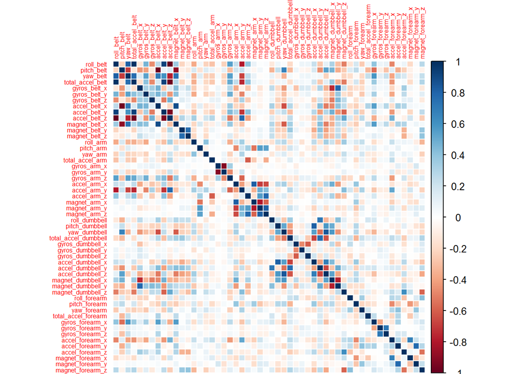